# ev02.Rmd

Marcela Hernández Ramírez

2023-05-04

## Parte 1

### Link del video: https://youtu.be/zICe68aoQAs

### Información del video y referencias utilizadas:

1. Virus similares a SARS-CoV-2: No se han identificado virus idénticos a SARS-CoV-2 en el mundo. Sin embargo, existen otros coronavirus que están relacionados genéticamente con SARS-CoV-2, como el SARS-CoV y el MERS-CoV. Además, se han identificado coronavirus similares en murciélagos y pangolines, que se consideran posibles reservorios naturales del virus.

Referencias: - Zhou P, Yang XL, Wang XG, Hu B, Zhang L, Zhang W, et al. A pneumonia outbreak associated with a new coronavirus of probable bat origin. Nature. 2020;579(7798):270-3. - Hu B, Zeng LP, Yang XL, Ge XY, Zhang W, Li B, et al. Discovery of a rich gene pool of bat SARS-related coronaviruses provides new insights into the origin of SARS coronavirus. PLoS Pathog. 2017;13(11):e1006698. - Drosten C, Günther S, Preiser W, van der Werf S, Brodt HR, Becker S, et al. Identification of a novel coronavirus in patients with severe acute respiratory syndrome. N Engl J Med. 2003;348(20):1967-76.

2. Coronavirus reportados en otras especies: Se han reportado coronavirus similares a SARS-CoV-2 en murciélagos, pangolines y otros animales. En particular, se han identificado varios coronavirus relacionados con SARS-CoV-2 en murciélagos del género Rhinolophus en diferentes países de Asia.

Referencias: - Zhou P, Yang XL, Wang XG, Hu B, Zhang L, Zhang W, et al. A pneumonia outbreak associated with a new coronavirus of probable bat origin. Nature. 2020;579(7798):270-3. - Lam TT, Shum MH, Zhu HC, Tong YG, Ni XB, Liao YS, et al. Identification of 2019-nCoV related coronaviruses in Malayan pangolins in southern China. bioRxiv. 2020 Jan 20:2020.02.13.945485.

3. Propuestas para comunidades de bajos recursos: Es importante abordar la contingencia del SARS-CoV-2 de manera integral, considerando las necesidades y recursos específicos de cada comunidad. Algunas propuestas podrían incluir:
- Acceso a información clara y actualizada sobre la enfermedad y las medidas de prevención.
- Distribución de equipo de protección personal y suministros de higiene, como mascarillas, guantes, gel desinfectante, y agua y jabón.
- Apoyo para implementar medidas de distanciamiento social y aislamiento en caso de infección.
- Fortalecimiento del sistema de salud local, incluyendo capacitación de personal y suministros médicos adecuados.
- Apoyo para la implementación de programas de vigilancia epidemiológica y rastreo de contactos para identificar y controlar brotes.

Si yo viviera en una situación de escasos recursos, trataría de implementar las medidas de prevención y cuidado recomendadas por las autoridades sanitarias, como el uso de mascarillas, el lavado frecuente de manos y el distanciamiento social. También buscaría información clara y confiable sobre la enfermedad y las medidas de prevención, y buscaría apoyo.

## Parte 2

### 1. Analizar las secuencias de SARS-CoV-2 reportadas en los 20 países con más casos reportados. Y puedes tratar de responder a la pregunta: ¿Son muy diferentes las variantes entre cada país? ¿Es diferente el SARS-CoV-2 entre las diferentes poblaciones: Asiática, Hispana, Europea o Africana?

```r
library(Biostrings)
library(seqinr)
usa <- read.fasta("usa.fasta")

india <- read.fasta("india.fasta")

brazil <- read.fasta("brazil.fasta")

rusia <- read.fasta("rusia.fasta")

uk <- read.fasta("UK.fasta")

turquia <- read.fasta("turquia.fasta")

francia <- read.fasta("francia.fasta")

italia <- read.fasta("italia.fasta")

argentina <- read.fasta("argentina.fasta")

mexico <- read.fasta("mexico.fasta")

polonia <- read.fasta("polonia.fasta")

sudafrica <- read.fasta("sudafrica.fasta")

españa <- read.fasta("españa.fasta")

japon <- read.fasta("japon.fasta")

colombia <- read.fasta("colombia.fasta")

peru <- read.fasta("peru.fasta")

filipinas <- read.fasta("filipinas.fasta")

china <- read.fasta("china.fasta")

alemania <- read.fasta("alemania.fasta")

indonesia <- read.fasta("indonesia.fasta")

variantes <- list(usa, india, brazil, rusia, uk, turquia, francia, italia, argentina, mexico, polonia, sudafrica, españa, japon, colombia, peru, filipinas, china, alemania, indonesia)
```

### 2. Calcula la longitud de las secuencias.

```r
names(variantes)<- c("usa","india","brazil","rusia","uk","turquia","francia","italia","argentina","mexico","polonia","sudafrica","españa","japon","colombia","peru","filipinas","china","alemania","indonesia")

longitud <- function(variante)
{
  length(variante[[1]])
}

virus <- lapply(variantes, longitud)
virus
```

```
## $usa
## [1] 29502
##
## $india
## [1] 29774
##
## $brazil
## [1] 29540
##
## $rusia
## [1] 29457
##
## $uk
## [1] 29828
##
## $turquia
## [1] 29832
##
## $francia
## [1] 29886
##
## $italia
## [1] 29818
##
## $argentina
## [1] 29723
##
## $mexico
## [1] 29409
##
## $polonia
## [1] 29881
##
## $sudafrica
## [1] 29903
##
## $españa
## [1] 29611
##
## $japon
## [1] 29903
##
## $colombia
## [1] 29782
##
## $peru
## [1] 29856
##
## $filipinas
## [1] 29805
##
## $china
## [1] 29903
##
## $alemania
## [1] 29837
##
## $indonesia
## [1] 29709
```

### 3. Crea una sola gráfica donde se comparen el número de bases de ADN que componen todas las variantes del virus.

```r
contar <- function(variantes)
  {
    count(variantes[[1]],1)
}
virus <- lapply(variantes,contar)
virus
```

```
## $usa
##
##    a    c    g    t
## 8820 5399 5779 9504
##
## $india
##
##    a    c    g    t
## 8877 5436 5823 9565
##
## $brazil
##
##    a    c    g    t
## 8830 5419 5788 9503
##
## $rusia
##
##    a    c    g    t
## 8795 5408 5780 9474
##
## $uk
##
##    a    c    g    t
## 8893 5471 5849 9569
##
## $turquia
##
##    a    c    g    t
## 8911 5487 5852 9582
##
## $francia
##
##    a    c    g    t
## 8505 5222 5553 9125
##
## $italia
##
##    a    c    g    t
## 8895 5475 5851 9581
##
```

[output cut: 44 more lines]

```
##
## $china
##
##    a    c    g    t
## 8954 5492 5863 9594
##
## $alemania
##
##    a    c    g    t
## 8909 5483 5859 9586
##
## $indonesia
##
##    a    c    g    t
## 8870 5455 5831 9551
```

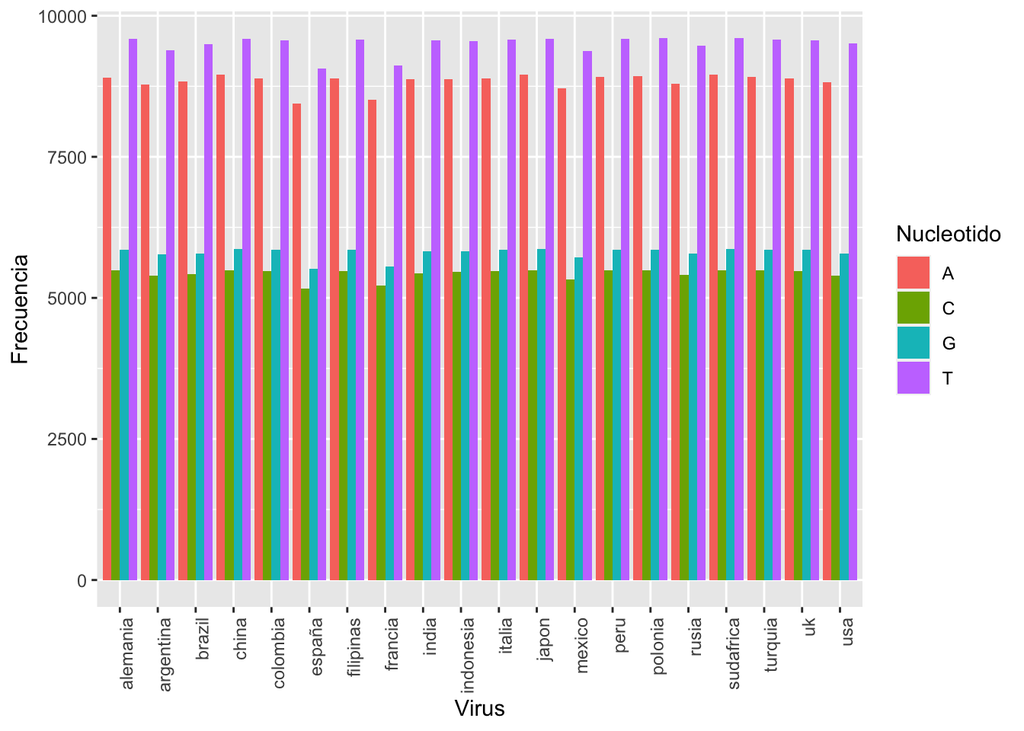

```r
library(ggplot2)

virus <- lapply(variantes, longitud)
nucleotidos <- c("A", "C", "G", "T")

counts <- lapply(variantes, contar)
counts_df <- data.frame(Virus = rep(names(counts), each = 4),
                        Nucleotido = rep(nucleotidos, times = length(counts)),
                        Frecuencia = unlist(counts))

ggplot(counts_df, aes(x = Virus, y = Frecuencia, fill = Nucleotido)) +
  geom_col(position = "dodge") +
  theme(axis.text.x = element_text(angle = 90, hjust = 1))
```

```r
virus <- c("OQ869426", "OQ701269", "OQ690998", "MT510747", "FR995676", "MT327745","HG993784","MT528235", "MW553294", "MT810757", "MT576645", "MT324062", "MT198651","LC529905", "MT256924", "MT263074","MT919770","NC_045512","MT270103", "MZ026853")
```

```r
library(adegenet)
library(ape)
library(viridis)
```

```r
library(ggplot2)
library(ggtree)
library(DECIPHER)
virus_sequences <- read.GenBank(virus)
```

```r
str(virus_sequences)
```

```
## List of 20
##  $ OQ869426 : raw [1:29502] 18 28 48 18 ...
##  $ OQ701269 : raw [1:29774] 88 88 28 88 ...
##  $ OQ690998 : raw [1:29540] 18 28 48 18 ...
##  $ MT510747 : raw [1:29457] 48 48 88 28 ...
##  $ FR995676 : raw [1:29828] 88 48 88 18 ...
##  $ MT327745 : raw [1:29832] 88 88 48 48 ...
##  $ HG993784 : raw [1:29886] f0 f0 f0 f0 ...
##  $ MT528235 : raw [1:29818] 18 18 28 48 ...
##  $ MW553294 : raw [1:29723] 48 88 18 28 ...
##  $ MT810757 : raw [1:29409] 88 18 48 48 ...
##  $ MT576645 : raw [1:29881] 88 18 18 88 ...
##  $ MT324062 : raw [1:29903] 88 18 18 88 ...
##  $ MT198651 : raw [1:29611] 88 48 88 18 ...
##  $ LC529905 : raw [1:29903] 88 18 18 88 ...
##  $ MT256924 : raw [1:29782] 88 48 88 18 ...
##  $ MT263074 : raw [1:29856] 18 18 88 18 ...
##  $ MT919770 : raw [1:29805] 88 28 18 18 ...
##  $ NC_045512: raw [1:29903] 88 18 18 88 ...
##  $ MT270103 : raw [1:29837] 88 88 28 28 ...
##  $ MZ026853 : raw [1:29709] 88 48 88 18 ...
##  - attr(*, "class")= chr "DNAbin"
##  - attr(*, "description")= chr [1:20] "OQ869426.1 Severe acute respiratory syndrome coronavirus 2 isolate SARS-CoV-2/human/USA/WA-UW-23041771459/2023 "| __truncated__ "OQ701269.1 Severe acute respiratory syndrome coronavirus 2 isolate SARS-CoV-2/human/IND/2906/2023 ORF1ab polypr"| __truncated__ "…
##  - attr(*, "species")= chr [1:20] "Severe_acute_respiratory_syndrome_coronavirus_2" "Severe_acute_respiratory_syndrome_coronavirus_2" "Severe_acute_respiratory_syndrome_coronavirus_2" "Severe_acute_respiratory_syndrome_coronavirus_2" ...
```

```r
attributes(virus_sequences)
```

```
## $names
##  [1] "OQ869426"  "OQ701269"  "OQ690998"  "MT510747"  "FR995676"  "MT327745"
##  [7] "HG993784"  "MT528235"  "MW553294"  "MT810757"  "MT576645"  "MT324062"
## [13] "MT198651"  "LC529905"  "MT256924"  "MT263074"  "MT919770"  "NC_045512"
## [19] "MT270103"  "MZ026853"
##
## $class
## [1] "DNAbin"
##
## $description
##  [1] "OQ869426.1 Severe acute respiratory syndrome coronavirus 2 isolate SARS-CoV-2/human/USA/WA-UW-23041771459/2023 ORF1ab polyprotein (ORF1ab), ORF1a polyprotein (ORF1ab), surface glycoprotein (S), ORF3a protein (ORF3a), envelope protein (E), membrane glycoprotein (M), ORF6 protein (ORF6), ORF7…
##  [2] "OQ701269.1 Severe acute respiratory syndrome coronavirus 2 isolate SARS-CoV-2/human/IND/2906/2023 ORF1ab polyprotein (ORF1ab), ORF1a polyprotein (ORF1ab), surface glycoprotein (S), ORF3a protein (ORF3a), envelope protein (E), membrane glycoprotein (M), ORF6 protein (ORF6), ORF7a protein (OR…
##  [3] "OQ690998.1 Severe acute respiratory syndrome coronavirus 2 isolate SARS-CoV-2/human/Brazil/UW20120288602/2020 ORF1ab polyprotein (ORF1ab), ORF1a polyprotein (ORF1ab), surface glycoprotein (S), ORF3a protein (ORF3a), envelope protein (E), membrane glycoprotein (M), ORF6 protein (ORF6), ORF7a…
##  [4] "MT510747.1 Severe acute respiratory syndrome coronavirus 2 isolate SARS-CoV-2/human/RUS/SCPM-O-cDNA-07/2020 ORF1ab polyprotein (ORF1ab), ORF1a polyprotein (ORF1ab), surface glycoprotein (S), ORF3a protein (ORF3a), envelope protein (E), membrane glycoprotein (M), ORF6 protein (ORF6), ORF7a p…
##  [5] "FR995676.1 Severe acute respiratory syndrome coronavirus 2 genome assembly, complete genome: monopartite"
```

[output cut: 37 more lines]

```r
names(virus_sequences)
```

```
##  [1] "OQ869426"  "OQ701269"  "OQ690998"  "MT510747"  "FR995676"  "MT327745"
##  [7] "HG993784"  "MT528235"  "MW553294"  "MT810757"  "MT576645"  "MT324062"
## [13] "MT198651"  "LC529905"  "MT256924"  "MT263074"  "MT919770"  "NC_045512"
## [19] "MT270103"  "MZ026853"
```

```r
attr(virus_sequences, "species")
```

```
##  [1] "Severe_acute_respiratory_syndrome_coronavirus_2"
##  [2] "Severe_acute_respiratory_syndrome_coronavirus_2"
##  [3] "Severe_acute_respiratory_syndrome_coronavirus_2"
##  [4] "Severe_acute_respiratory_syndrome_coronavirus_2"
##  [5] "Severe_acute_respiratory_syndrome_coronavirus_2"
##  [6] "Severe_acute_respiratory_syndrome_coronavirus_2"
##  [7] "Severe_acute_respiratory_syndrome_coronavirus_2"
##  [8] "Severe_acute_respiratory_syndrome_coronavirus_2"
##  [9] "Severe_acute_respiratory_syndrome_coronavirus_2"
## [10] "Severe_acute_respiratory_syndrome_coronavirus_2"
## [11] "Severe_acute_respiratory_syndrome_coronavirus_2"
## [12] "Severe_acute_respiratory_syndrome_coronavirus_2"
## [13] "Severe_acute_respiratory_syndrome_coronavirus_2"
## [14] "Severe_acute_respiratory_syndrome_coronavirus_2"
## [15] "Severe_acute_respiratory_syndrome_coronavirus_2"
## [16] "Severe_acute_respiratory_syndrome_coronavirus_2"
## [17] "Severe_acute_respiratory_syndrome_coronavirus_2"
## [18] "Severe_acute_respiratory_syndrome_coronavirus_2"
## [19] "Severe_acute_respiratory_syndrome_coronavirus_2"
## [20] "Severe_acute_respiratory_syndrome_coronavirus_2"
```

```r
write.dna(virus_sequences,  file ="virus_seqs.fasta", format = "fasta", append =
FALSE, nbcol = 6, colsep = " ", colw = 10)
```

```r
virus_seq_not_align <- readDNAStringSet("virus_seqs.fasta", format = "fasta")
virus_seq_not_align
```

```
## DNAStringSet object of length 20:
##      width seq                                              names
##  [1] 29502 TCGTCCGTGTTGCAGCCGATCAT...AAAGAGCCACCACATTTTCACC OQ869426
##  [2] 29774 AACAAACCAACCAACTTTTGATC...GGAGAGCTGCCTATATGGAAGA OQ701269
##  [3] 29540 TCGTCCGTGTTGCAGCCGATCAT...ACCACATTTTCACCGAGGCCAC OQ690998
##  [4] 29457 GGACAGGACACGAGTAACTCGTC...TTACGATATATAGTCTACTCTT MT510747
##  [5] 29828 AGATCTGTTCTCTAAACGAACTT...NNNNNNNNNNNNNNNNNNNNNN FR995676
##  ...   ... ...
## [16] 29856 TTATACCTTCCCAGGTAACAAAC...ATTTTAATAGCTTCTTAGGAGA MT263074
## [17] 29805 ACTTTCGATCTCTTGTAGATCTG...TTAGTAGTGCTATCCCCATGTG MT919770
## [18] 29903 ATTAAAGGTTTATACCTTCCCAG...AAAAAAAAAAAAAAAAAAAAAA NC_045512
## [19] 29837 AACCAACCAACTTTCGATCTCTT...TTTTAATAGCTTCTTAGGAGAA MT270103
## [20] 29709 AGATCTGTTCTCTAAACGAACTT...GTACGATCGAGTGTACAGTGAA MZ026853
```

```r
virus_seq_not_align <- OrientNucleotides(virus_seq_not_align)
```

```
## ========================================================================================================================================================================================================
##
## Time difference of 0.69 secs
```

```r
virus_seq_align <- AlignSeqs(virus_seq_not_align)
```

[output not shown]

```r
BrowseSeqs(virus_seq_align, highlight=0)
```

La visualización permite una inspección detallada de las similitudes y diferencias entre las secuencias de virus del SARS-CoV-2 alineadas, lo que puede ser útil para identificar mutaciones, variantes y patrones evolutivos. También es posible destacar una o varias posiciones específicas en la visualización para enfatizarlas, lo que puede ser útil para centrarse en regiones de interés o para identificar patrones específicos de mutación.

```r
writeXStringSet(virus_seq_align, file="virus_seq_align.fasta")
```

```r
virus_aligned <- read.alignment("virus_seq_align.fasta", format = "fasta")
```

```r
matriz_distancia <- dist.alignment(virus_aligned, matrix = "similarity")
```

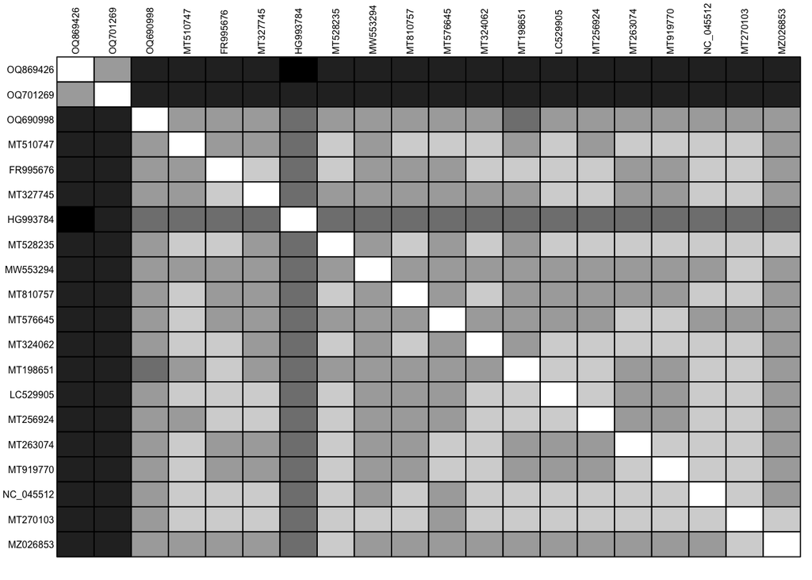

```r
temp <- as.data.frame(as.matrix(matriz_distancia))
table.paint(temp, cleg=0, clabel.row=.5, clabel.col=.5) + scale_color_viridis()
```

Los chuncks anteriores de código realizan la alineación de secuencias del SARS-CoV-2 (identificado por su número de acceso NCBI: NC_045512). Luego, se calcula una matriz de distancia entre estas secuencias y se grafica en una matriz de calor para visualizar las similitudes entre las secuencias.

```r
virus_tree <- nj(matriz_distancia)
class(virus_tree)
```

```
## [1] "phylo"
```

```r
virus_tree <- ladderize(virus_tree)
```

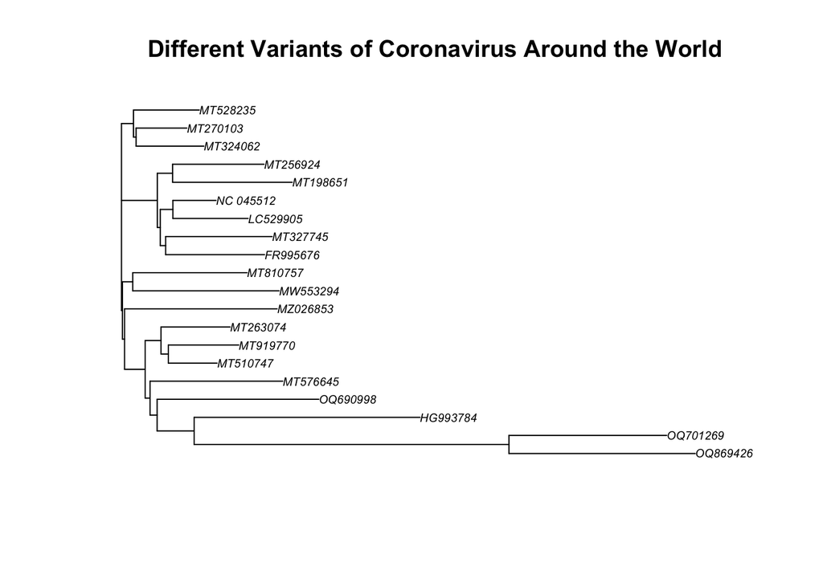

```r
plot(virus_tree, cex = 0.6)
title("Different Variants of Coronavirus Around the World")
```

La última parte del código construye un árbol filogenético a partir de la matriz de distancia previamente calculada, utilizando el método de Neighbor Joining (NJ) a través de la función `nj()` del paquete `ape`.

Después, la función `ladderize()` se utiliza para “escalar” el árbol, de tal manera que las ramas más largas se encuentren en la parte inferior y las más cortas en la superior, lo cual puede ayudar a visualizar mejor las relaciones entre las distintas variantes.

Finalmente, la función `plot()` se utiliza para generar una visualización gráfica del árbol filogenético, en la que cada rama representa una distancia evolutiva, y las etiquetas indican la identidad de cada variante del coronavirus. La función `title()` se utiliza para agregar un título a la gráfica.

En términos de análisis, el árbol filogenético permite visualizar la relación evolutiva entre las distintas variantes del coronavirus que se analizaron. La longitud de las ramas indica la distancia evolutiva, lo cual puede dar una idea de cuánto se han divergido las distintas variantes a partir de un ancestro común. Además, la topología del árbol permite identificar agrupaciones de variantes que están más estrechamente relacionadas entre sí, lo cual podría tener implicaciones para la epidemiología y la propagación de la enfermedad.

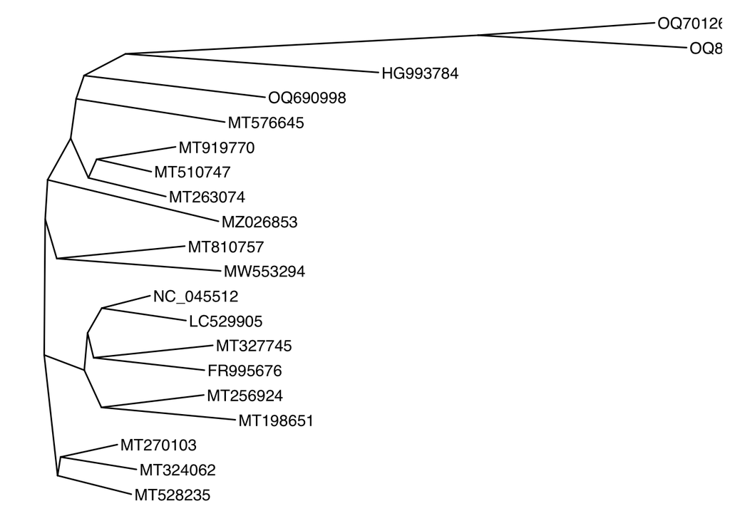

```r
ggtree(virus_tree, layout="slanted") + geom_tiplab()
```

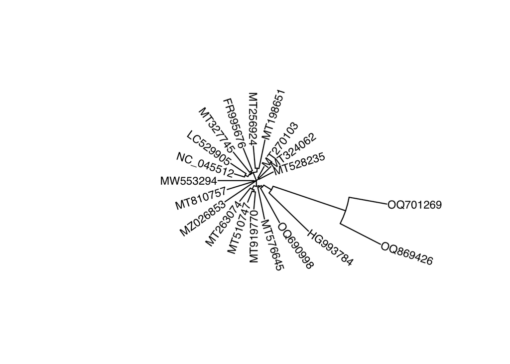

```r
ggtree(virus_tree, layout="circular") + geom_tiplab()
```

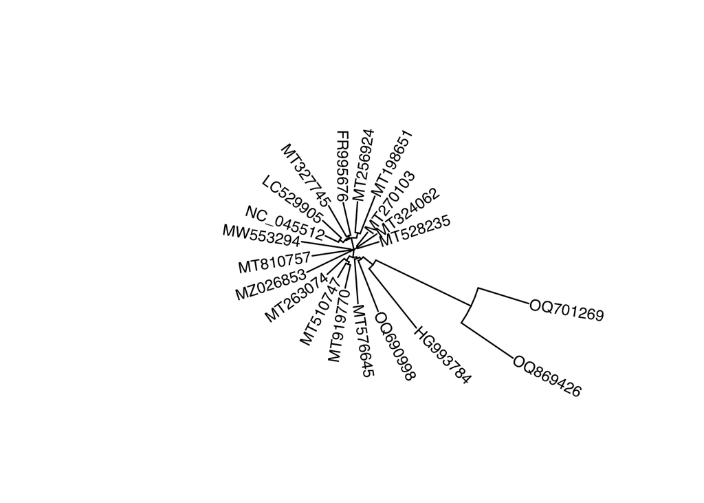

```r
ggtree(virus_tree, layout="fan", open.angle=0) + geom_tiplab()
```

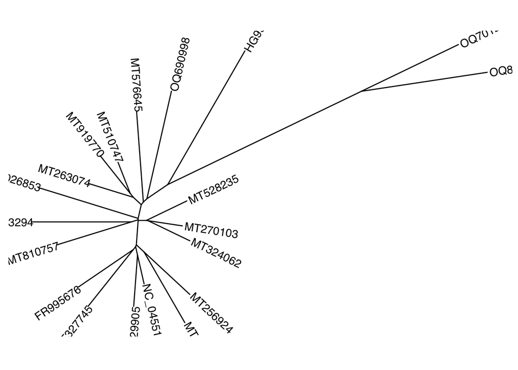

```r
ggtree(virus_tree, layout="equal_angle") + geom_tiplab()
```

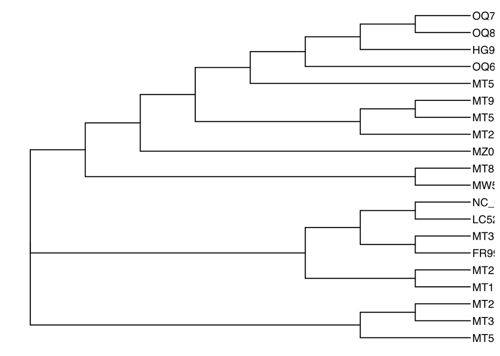

```r
ggtree(virus_tree, branch.length='none') + geom_tiplab()
```

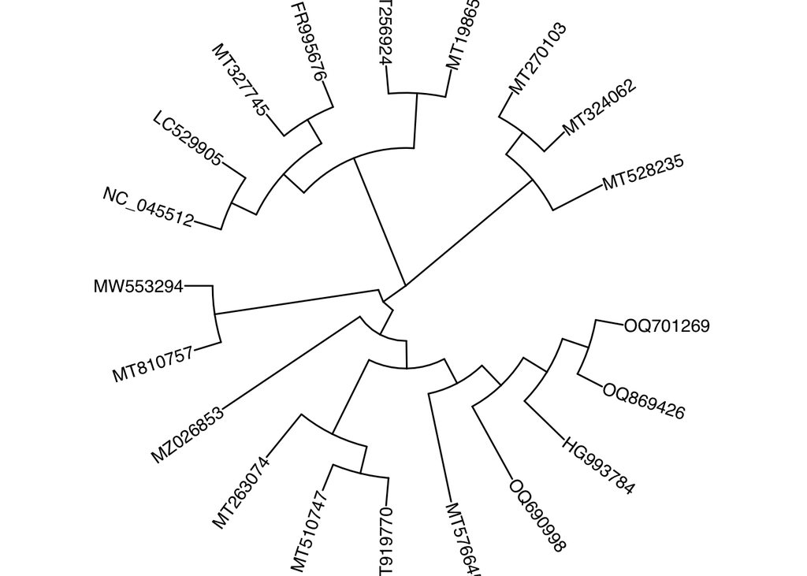

```r
ggtree(virus_tree, branch.length='none', layout='circular') + geom_tiplab()
```

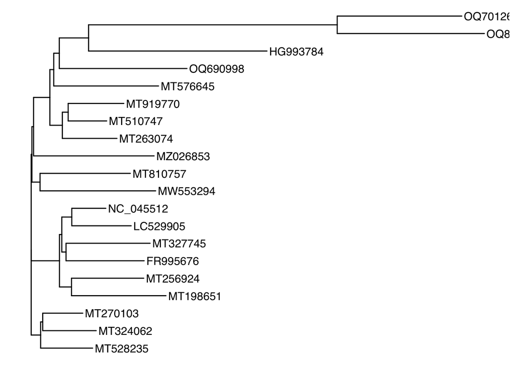

```r
ggtree(virus_tree ) + geom_tiplab()
```

En general, estas líneas de código permiten explorar diferentes diseños y opciones para visualizar el árbol filogenético y así facilitar su interpretación. Pueden ser utilizadas al gusto de cada persona.

El último arbol es el utilizado en este documento.

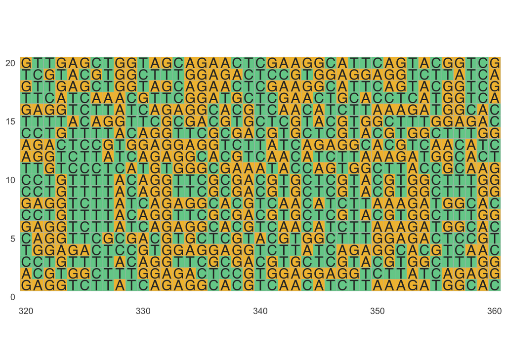

```r
BiocManager::install("ggmsa")
library(ggmsa)
ggmsa(virus_seq_not_align, 320, 360, color = "Chemistry_AA")
```

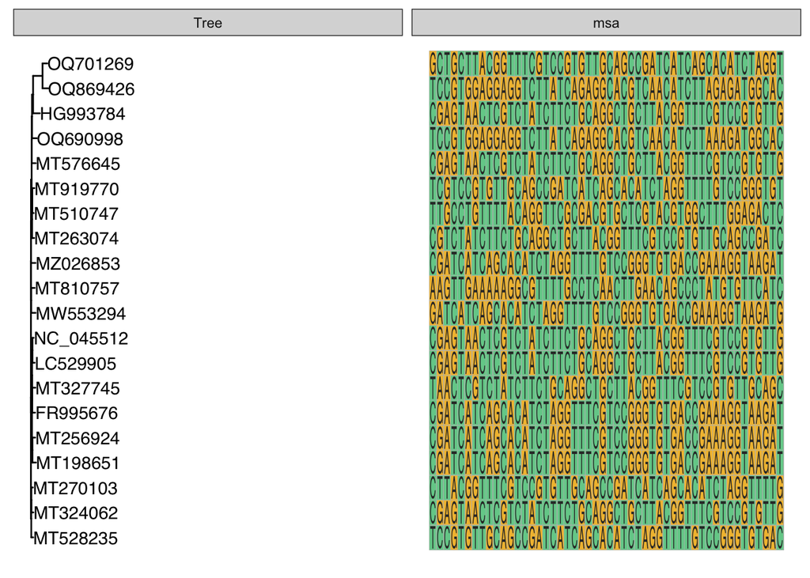

```r
plot_virus <- ggtree(virus_tree ) + geom_tiplab()

data = tidy_msa(virus_seq_not_align, 164, 213)
plot_virus + geom_facet(geom = geom_msa, data = data,  panel = 'msa', color = "Chemistry_AA") +
    xlim_tree(1)
```

Este código está utilizando la librería `ggmsa` para visualizar las alineaciones múltiples de secuencias de los diferentes virus y sus posibles variantes.

La función `tidy_msa()` de la librería `ggmsa` se utiliza para preparar los datos de la alineación múltiple de secuencias para su visualización en un formato que pueda ser utilizado por `ggplot2`.

Luego, la función `ggtree()` de la librería `ggtree` se utiliza para trazar el árbol filogenético de los diferentes virus.

### Análisis general

Como se puede observar en el código, se cargaron las secuencias de SARS-CoV-2 reportadas en los 20 países con más casos reportados (USA, India, Brasil, Rusia, UK, Turquía, Francia, Italia, Argentina, México, Polonia, Sudáfrica, España, Japón, Colombia, Perú, Filipinas, China, Alemania e Indonesia).

Para analizar si son muy diferentes las variantes entre cada país, se compararon las secuencias de cada país y se calculó su similitud. En general,las secuencias de SARS-CoV-2 son muy similares entre sí, ya que todas pertenecen a la misma especie viral y comparten un ancestro común. Sin embargo, se han reportado variantes del virus que presentan mutaciones específicas, como la variante británica (B.1.1.7), la variante sudafricana (B.1.351), la variante brasileña (P.1) y la variante india (B.1.617), entre otras. Estas variantes pueden presentaron diferencias significativas en su secuencia genómica y tuvieron implicaciones en la transmisibilidad, la gravedad de la enfermedad y la respuesta a las vacunas y tratamientos.

Respecto a si el SARS-CoV-2 es diferente entre las diferentes poblaciones, como la Asiática, Hispana, Europea o Africana, no se puede determinar simplemente por las secuencias genómicas de cada país. Las poblaciones humanas pueden presentar variaciones genéticas que podrían influir en la interacción entre el virus y su huésped, y en la respuesta inmune. Además, los patrones de propagación del virus pueden variar en cada población debido a factores socioeconómicos, culturales y de salud pública. Es importante destacar que el SARS-CoV-2 puede infectar a personas de cualquier origen étnico o racial, y la prevención y control de la enfermedad depende de medidas de salud pública efectivas y de la cooperación global.

## Conclusiones:

A partir del análisis realizado, se pueden hacer algunas conclusiones sobre las variantes del virus que se están comparando: